# Milestone report

This report includes some basci exploratory analysis of the dataset for swiftkey capstone project.

There are three files in the original dataset, representing blog posts, news and tweets respectively. Here is a basic summary of the three original files.

|  | line.counts | word.counts |
| --- | --- | --- |
| blogs | 899288 | 37334690 |
| news | 1010242 | 34372720 |
| twitter | 2360148 | 30374206 |

At this exploratory stage, I chose to use a smaller subset of the data (1/100). The toy dataset looks like this:

|  | line.counts | word.counts |
| --- | --- | --- |
| blogs | 8991 | 367066 |
| news | 9964 | 336223 |
| twitter | 23413 | 301261 |

After some cleaning (cases, puctuations, whitespaces and stopwords), let's take a look at the distributions of word frequencies in these three corpora.

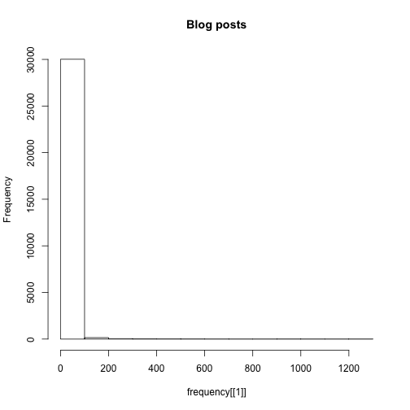

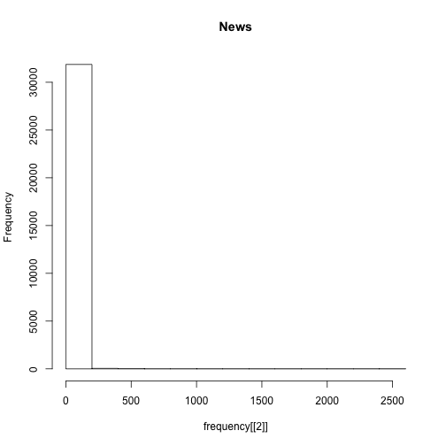

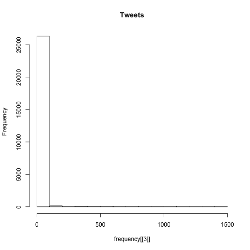

As we can see, most words don't appear that frequently. So what are the most frequent ones?

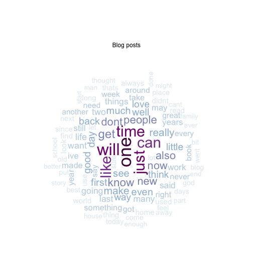

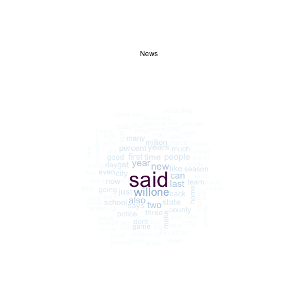

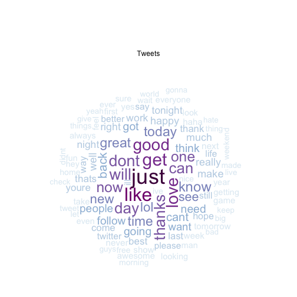

|  | N50 | N90 |
| --- | --- | --- |
| Blogs | 942 | 12667 |
| News | 1202 | 13683 |
| Tweets | 529 | 10220 |

As we can see from the table above, with those most frequent ones, it takes 1202 words to cover 50% of all word instances in news while only 529 words are needed in tweets.

Since we are going to build predictive models, let's take a look at the 2-gram level.

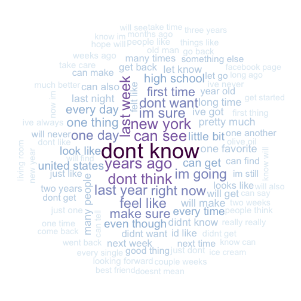

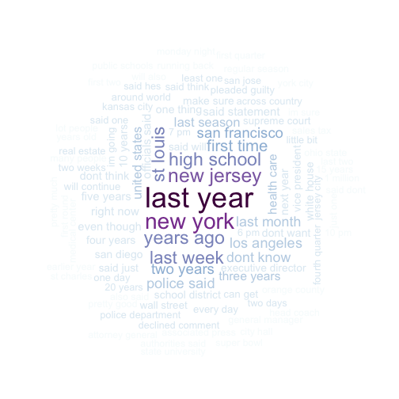

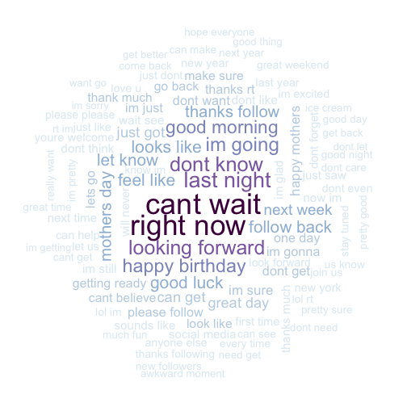

Seems to make sense. Now the tentative plan is to build the predictive model around the frequency of the 2-grams.

More later!